# Tracking Variables

Suppose we have a variable rate of exposure, and we want to formulate models in which recent exposure affects the epidemiology of disease. We construct the following two time series tracking exposure:

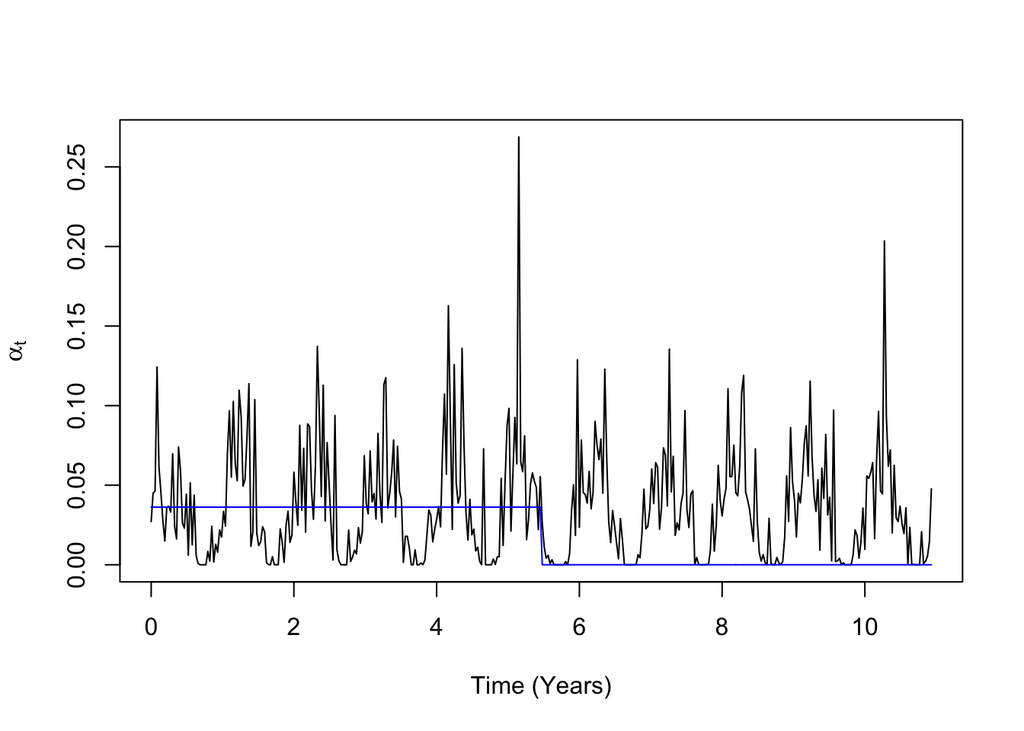

## Base PIT Variables: Exposure Tracking

In a population stratified by age, cumulative exposure will vary by age. Let $V_{a,t}$ denote an immune tracking variable that tracks exposure for people of age $a$ at time $t$. It is updated by the following recursive relationship:

$$\begin{equation}
V_{a,t+1} = \sigma \alpha_t + (1-\mu) V_{a,t}
\end{equation}$$

Note that for $\mu=0$ and $\sigma=1$, the equation simply tracks cumulative exposure. This version returns only the last value:

```r
basePIT.0 = function(alpha, mu=0, sigma = 1, vecV = matrix(0,1,1), calO=matrix(1,1,1), N=1, w=1){
  ###################################################################
  # If alpha is a vector (a time series), then N is its length.
  # If alpha is a scalar, then N is passed as an optional argument.
  # Default values update one time step for alpha and mu.
  ###################################################################
  if(length(alpha)==1){
    alpha = rep(alpha, N)
  } else {
    N = length(alpha)
  }
  # Setting sigma=0 "normalizes" the exposure to mu
  if(sigma==0){
    if(mu==0) print("WARNING: mu=sigma=0.")
    sigma = ifelse(mu==0, 1, mu)
  }
  ####################################
  # alpha is the "attack" rate
  # mu describes the "decay"
  # w describes biting weights by age
  # calO is an age operator
  ####################################
  for(t in 1:N){
    vecV = ((1-mu)*vecV + w*sigma*alpha[t])%*%calO
  }
  return(vecV)
}
```

This version returns the whole time series (including the initial value):

```r
basePIT.TS = function(alpha, mu=0, sigma = 1, vecV = matrix(0,1,1), calO=matrix(1,1,1), N=1, w=1){
  ###################################################################
  # If alpha is a vector (a time series), then N is its length.
  # If alpha is a scalar, then N is passed as an optional argument.
  # Default values update one time step for alpha and mu.
  ###################################################################
  if(length(alpha)==1){
    alpha = rep(alpha, N)
  } else {
    N = length(alpha)
  }
  # Setting sigma=0 "normalizes" the exposure to mu
  if(sigma==0){
    if(mu==0) print("WARNING: mu=sigma=0.")
    sigma = ifelse(mu==0, 1, mu)
  }
  ####################################
  # alpha is the "attack" rate
  # mu describes the "decay"
  # w describes biting weights by age
  # calO is an age operator
  ####################################
  matV = vecV
  for(t in 1:N){
    vecV = ((1-mu)*vecV + w*sigma*alpha[t])%*%calO
    matV = cbind(matV, vecV)
  }
  return(matV)
}
```

We write a function `plotPITxAge` that plots PIT variables by age.

```r
plotPITxAge = function(ages, vecV, lines=FALSE, clr=NULL, d2y=F){
  clr <- ifelse(is.null(clr),"black", clr)
  if(d2y == TRUE) ages <- ages/365
  if(lines==FALSE){
    plot(ages, vecV, type = "l", xlab = "Age (Years)", ylab = "PIT", col = clr)
  } else {
    lines(ages, vecV, col = clr)
  }
}
```

```r
source ("../Tensor-Model-Library/AgeOperators.R")
```

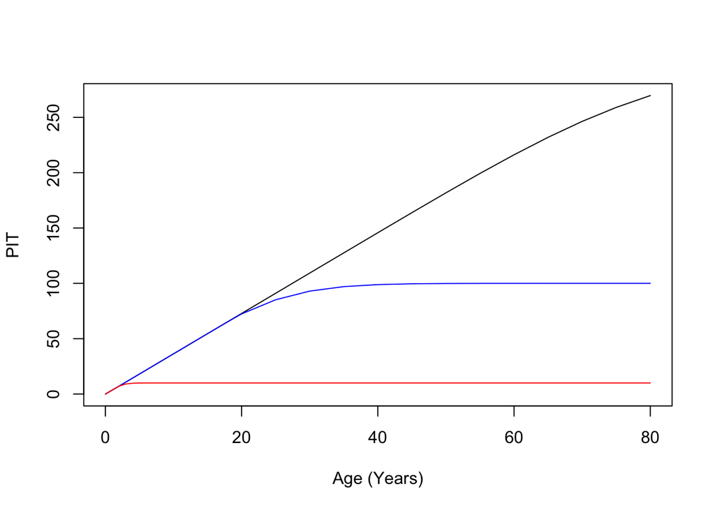

```r
calO = calO_1066()
ages = ages_1066()
vecV = matrix(0,1,66)

plotPITxAge(ages, basePIT.0(0.1, mu=0, sigma=1, vecV, calO, N=3000))
plotPITxAge(ages, basePIT.0(0.1, mu=0, sigma=1, vecV, calO, N=1000), T, "blue")
plotPITxAge(ages, basePIT.0(0.1, mu=0, sigma=1, vecV, calO, N=100), T,"red")
```

We plot another function, `plotPITxTime` that plots PIT variables over time.

```r
plotPITxTime = function(tm, vecV, lines=FALSE, clr=NULL, d2y=F){
  clr <- ifelse(is.null(clr),"black", clr)
  if(d2y == TRUE) tm <- tm/365
  if(lines==FALSE){
    plot(tm, vecV, type = "l", xlab = "Time (Years)", ylab = "PIT", col = clr)
  } else {
    lines(tm, vecV, col = clr)
  }
}
```

The following shows how the PIT variables behave with respect to time. Exposure is plotted in red. Other colors track exposure with decay:

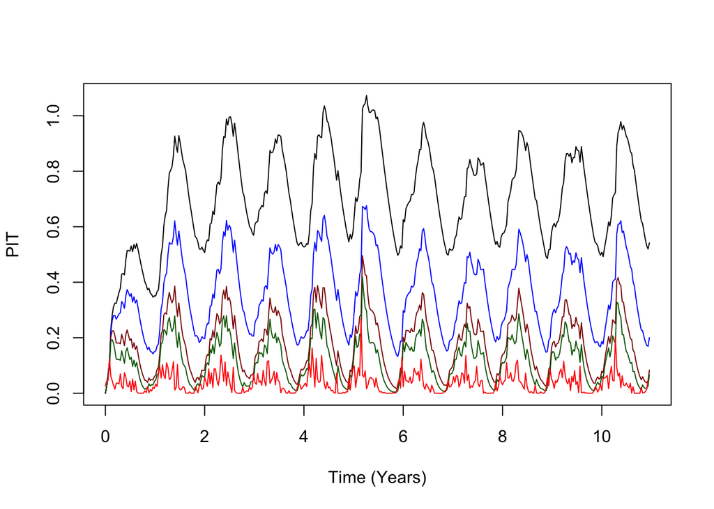

```r
vecV0 = 0
M11 = matrix(1,1,1)
plotPITxTime(ttTT, basePIT.TS(alphaT,0.05,1,vecV0)->V05)
plotPITxTime(ttTT, basePIT.TS(alphaT,0.1,1,vecV0)->V10, T, "blue")
plotPITxTime(ttTT, basePIT.TS(alphaT,0.2,1,vecV0)->V20, T,"darkred")
plotPITxTime(ttTT, basePIT.TS(alphaT,0.3,1,vecV0)->V30, T,"darkgreen")
#plotPITxTime(ttTT, basePIT.TS(alphaT, mu=0.5, alpha=1, vecV0)->V50, T,"purple")
lines(ttTT[-401], alphaT, col = "red")
```

This shows how the tracking variables work for constant exposure:

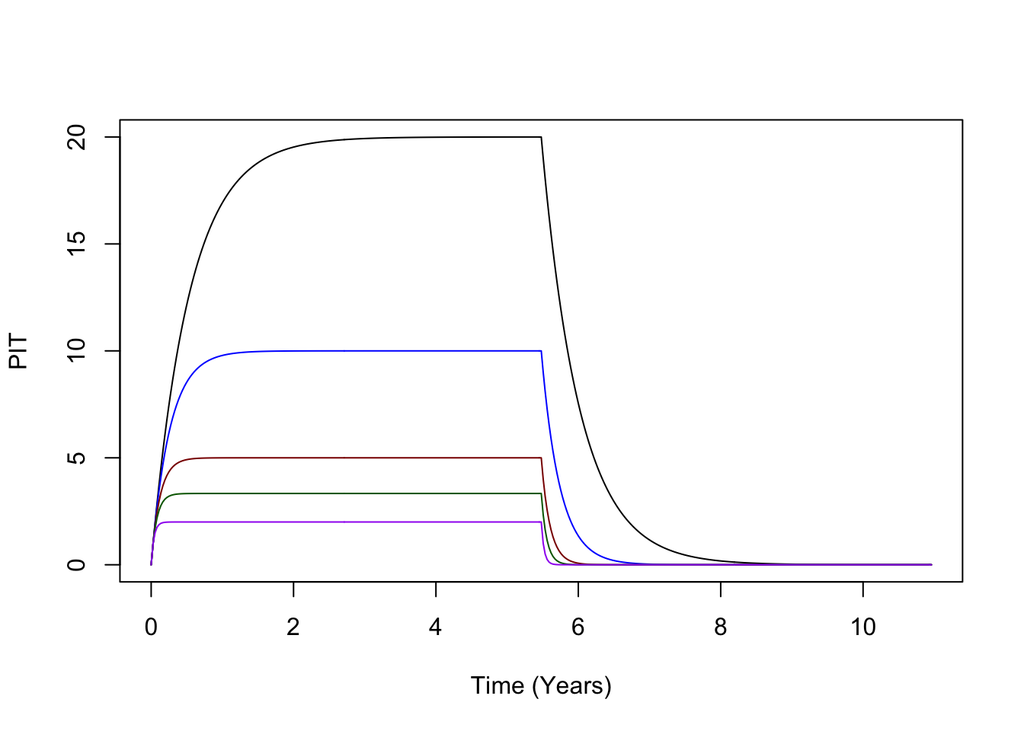

```r
vecV0 = 0
plotPITxTime(ttTT, basePIT.TS(stepT, 0.05, 1, vecV0)->V05)
plotPITxTime(ttTT, basePIT.TS(stepT, 0.1, 1, vecV0)->V10, T, "blue")
plotPITxTime(ttTT, basePIT.TS(stepT, 0.2, 1, vecV0)->V20, T,"darkred")
plotPITxTime(ttTT, basePIT.TS(stepT, 0.3, 1, vecV0)->V30, T,"darkgreen")
plotPITxTime(ttTT, basePIT.TS(stepT, 0.5, 1, vecV0)->V50, T,"purple")
```

Isolating the decay:

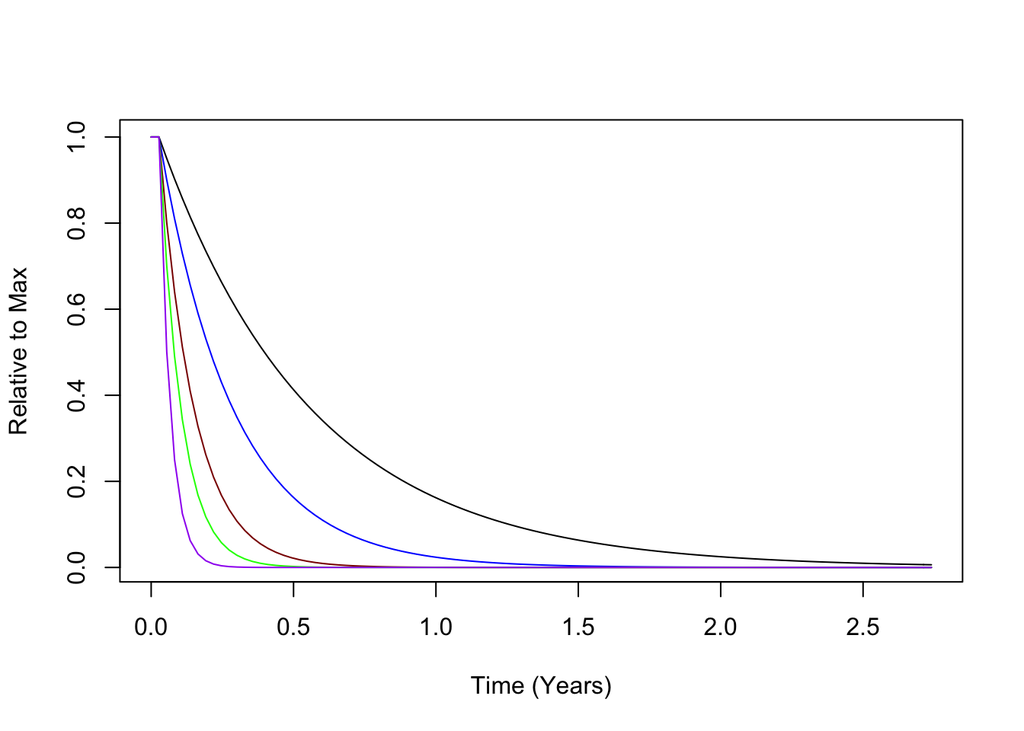

```r
ix = 200:300
tix = c(ix-200)/36.5
plot(tix, V05[ix]/max(V05), type = "l", xlab = "Time (Years)", ylab = "Relative to Max")
lines(tix,V10[ix]/max(V10), col = "blue")
lines(tix,V20[ix]/max(V20), col = "darkred")
lines(tix,V30[ix]/max(V30), col = "green")
lines(tix,V50[ix]/max(V50), col = "purple")
```

Note that passing $\sigma=0$ automatically “normalizes” the variables (setting $\sigma=\mu$), so that they have the same range:

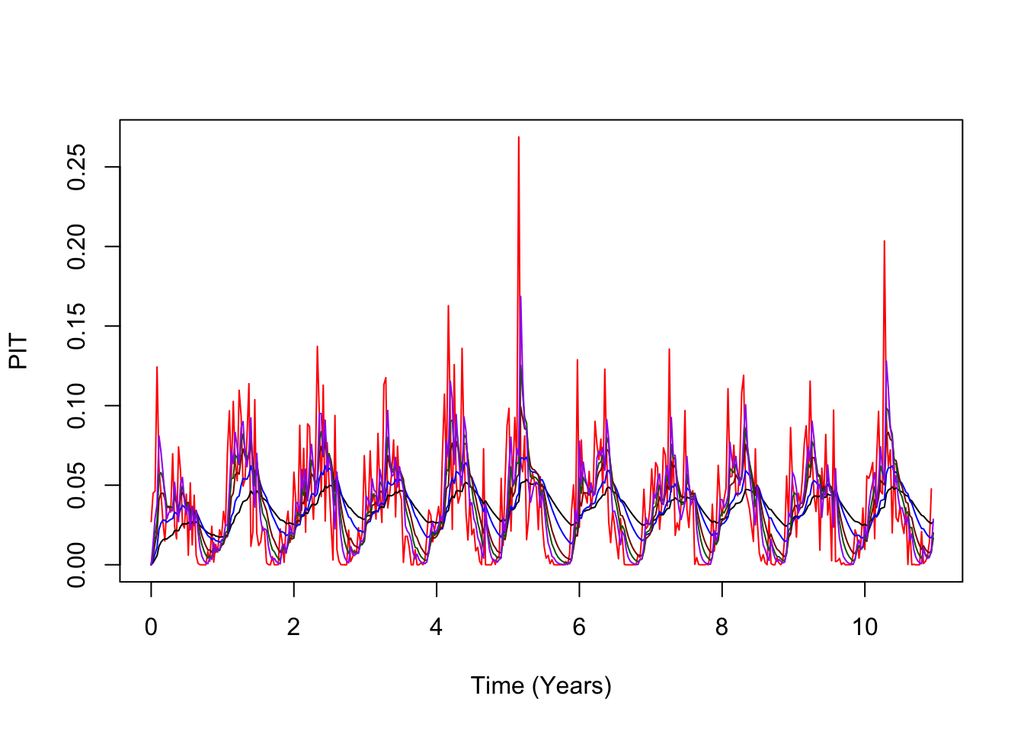

```r
vecV0 = 0
plot(ttTT[-401], alphaT, col = "red", xlab = "Time (Years)", ylab = "PIT", type="l")
plotPITxTime(ttTT, basePIT.TS(alphaT, mu=0.05, sigma=0, vecV0), T, "black")
plotPITxTime(ttTT, basePIT.TS(alphaT, mu=0.1, sigma=0, vecV0), T, "blue")
plotPITxTime(ttTT, basePIT.TS(alphaT, mu=0.2, sigma=0, vecV0), T,"darkred")
plotPITxTime(ttTT, basePIT.TS(alphaT, mu=0.3, sigma=0, vecV0), T,"darkgreen")
plotPITxTime(ttTT, basePIT.TS(alphaT, mu=0.5, sigma=0, vecV0), T,"purple")
```

Differences in the average value of $\alpha$ are still reflected in the time series that result:

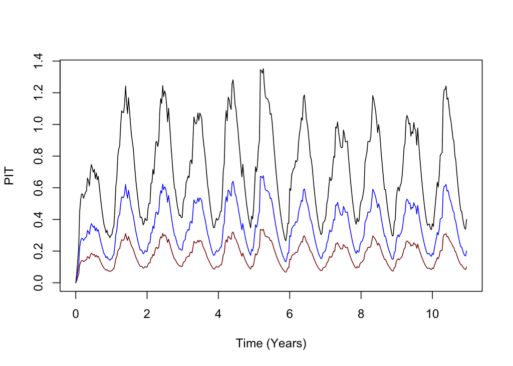

```r
vecV0 = 0
plotPITxTime(ttTT, basePIT.TS(2*alphaT,0.1,1, vecV0))
plotPITxTime(ttTT, basePIT.TS(alphaT,0.1, 1, vecV0), T, "blue")
plotPITxTime(ttTT, basePIT.TS(alphaT/2,0.1, 1, vecV0), T,"darkred")
```

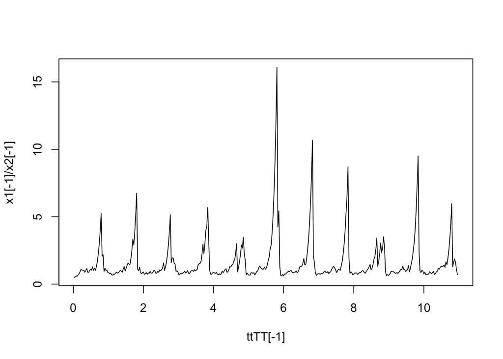

```r
x1 <- basePIT.TS(alphaT, 0.2, 0, vecV0)
x2 <- basePIT.TS(alphaT, 0.4 , 0, vecV0)
ix = ttTT[20:400]
plot(ttTT[-1], x1[-1]/x2[-1], type = "l")
```

## Logistic PIT Variables

Next, we use the logistic map, and we add a scaling parameter:
$$\begin{equation}
V_{a,t+1} = \left( \sigma \alpha_t + (1-\mu) V_{a,t} \right)\left(1-V_{a,t})
\end{equation}$$

```r
logisticPIT.0 = function(alpha, mu=0, sigma=1, vecV = matrix(0,1,1), calO=matrix(1,1,1), N=1, w=1){
  ###################################################################
  # If alpha is a vector (a time series), then N is its length.
  # If alpha is a scalar, then N is passed as an optional argument.
  # Default values update one time step for alpha and mu.
  ###################################################################
  if(length(alpha)==1){
    alpha = rep(alpha, N)
  } else {
    N = length(alpha)
  }
  # Setting sigma=0 "normalizes" the exposure to mu
  if(sigma==0){
    if(mu==0) print("WARNING: mu=sigma=0.")
    sigma = ifelse(mu==0, 1, mu)
  }
  ####################################
  # alpha is the "attack" rate
  # mu describes the "decay"
  # w describes biting weights by age
  # calO is an age operator
  ####################################
  for(t in 1:N){
    vecV = ((1-mu)*vecV + sigma*w*alpha[t])*(1-vecV)%*%calO
  }
  return(vecV)
}
```

This version returns the whole time series (including the initial value):

```r
logisticPIT.TS = function(alpha, mu=0, sigma=1, vecV = matrix(0,1,1), calO=matrix(1,1,1), N=1, w=1){
  ###################################################################
  # If alpha is a vector (a time series), then N is its length.
  # If alpha is a scalar, then N is passed as an optional argument.
  # Default values update one time step for alpha and mu.
  ###################################################################
  if(length(alpha)==1){
    alpha = rep(alpha, N)
  } else {
    N = length(alpha)
  }
  # Setting sigma=0 "normalizes" the exposure to mu
  if(sigma==0){
    if(mu==0) print("WARNING: mu=sigma=0.")
    sigma = ifelse(mu==0, 1, mu)
  }
  ####################################
  # alpha is the "attack" rate
  # mu describes the "decay"
  # w describes biting weights by age
  # calO is an age operator
  ####################################
  matV = vecV
  for(t in 1:N){
    vecV = ((1-mu)*vecV + sigma*w*alpha[t])*(1-vecV)%*%calO
    matV = cbind(matV, vecV)
  }
  return(matV)
}
```

## Age Scaling

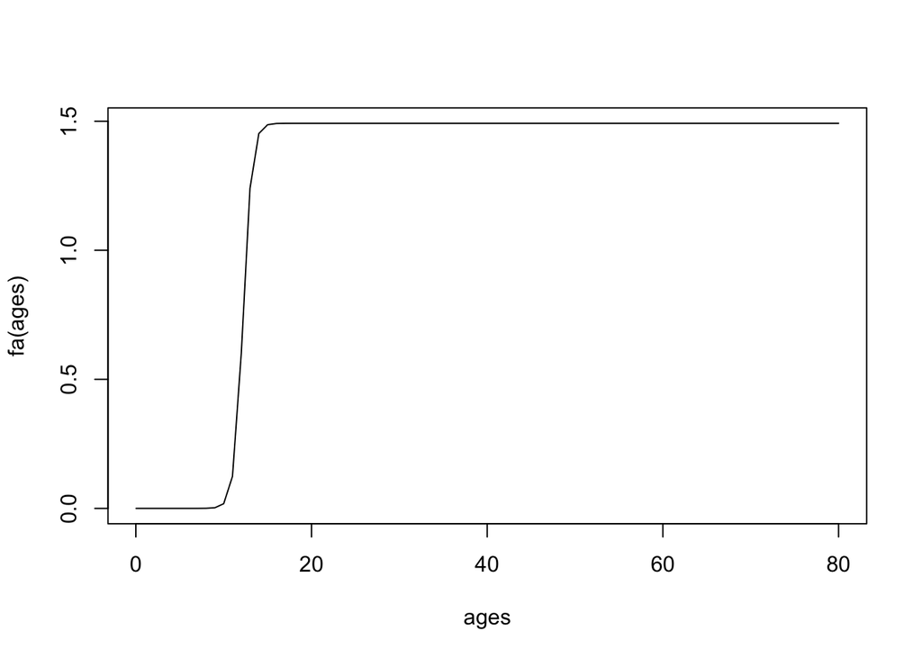

```r
fa = function(a, k1=20, min = 0.0001){
  1 / (exp(-k1/10/5) + exp(-k1*(a-12)/10)) + min
}
plot(ages, fa(ages), type = "l")
```